# Tuesday

Shih-Ni Prim 2020-10-16

- Introduction
- Setting the Value for the Parameter
- Data
- Splitting Data
- Summaries and Exploratory Data Analysis
- Fitting models
  - Regression tree
  - Boosted Tree
  - Linear Regression Model
  - Comparison
  - Final Model

## Introduction

Now we take a look at Tuesday’s analysis. This dataset contains information about [bike sharing](https://archive.ics.uci.edu/ml/datasets/Bike+Sharing+Dataset). We have a variety of predictors, including hours, temperature, humidity, weekday, holiday/workday or not, etc. In our analysis, We will use two statistical learning models–regression tree and boosted tree–to predict the count of total rental bikes `cnt`.

## Setting the Value for the Parameter

Since the current analysis is on Tuesday, we first find the corresponding value for it.

```r
set.seed(7777)
i <- 0:6
dayz <- c("Sunday", "Monday", "Tuesday", "Wednesday", "Thursday", "Friday", "Saturday")
df <- as.data.frame(cbind(i, dayz))
weekdayNum <- df$i[df$dayz == params$weekday]
print(weekdayNum)
```

```
## [1] "2"
```

## Data

Now we read in the data. Two datasets are listed on [the link](https://archive.ics.uci.edu/ml/datasets/Bike+Sharing+Dataset), one including the `hr` variable, and one treating each day as one observation and thus not including the `hr` variable. Since hours–the time in the day–should be a meaningful predictor for the number of bike rentals, we use the dataset with the `hr` variable

```r
bikes <- read_csv("Bike-Sharing-Dataset/hour.csv")
# head(bikes)
analysis <- bikes %>% filter(weekday == weekdayNum) %>% select(-casual, -registered) %>% select(dteday, weekday, everything())
# head(analysis)
```

## Splitting Data

We first split up the data into two sets: training and test sets. The training set has about 70% of the data, and the test set has about 30%. Splitting up the data is important, because we want to test the model on a set that is not used in training, otherwise we risk overfitting.

```r
train <- sample(1:nrow(analysis), size = nrow(analysis)*0.7)
test <- setdiff(1:nrow(analysis), train)

bikeTrain <- analysis[train,]
bikeTest <- analysis[test,]
```

## Summaries and Exploratory Data Analysis

To decide which variables to include in our models, we first take a quick look at the data. We can look at summaries of numerical variables.

```r
summary(bikeTrain)
```

```
##      dteday              weekday     instant          season
##  Min.   :2011-01-04   Min.   :2   Min.   :   70   Min.   :1.000
##  1st Qu.:2011-07-05   1st Qu.:2   1st Qu.: 4351   1st Qu.:2.000
##  Median :2011-12-27   Median :2   Median : 8540   Median :3.000
##  Mean   :2011-12-29   Mean   :2   Mean   : 8612   Mean   :2.533
##  3rd Qu.:2012-06-26   3rd Qu.:2   3rd Qu.:12907   3rd Qu.:3.000
##  Max.   :2012-12-25   Max.   :2   Max.   :17235   Max.   :4.000
##        yr              mnth              hr          holiday
##  Min.   :0.0000   Min.   : 1.000   Min.   : 0.0   Min.   :0.000000
##  1st Qu.:0.0000   1st Qu.: 4.000   1st Qu.: 6.0   1st Qu.:0.000000
##  Median :0.0000   Median : 7.000   Median :12.0   Median :0.000000
##  Mean   :0.4956   Mean   : 6.513   Mean   :11.6   Mean   :0.008154
##  3rd Qu.:1.0000   3rd Qu.: 9.000   3rd Qu.:18.0   3rd Qu.:0.000000
##  Max.   :1.0000   Max.   :12.000   Max.   :23.0   Max.   :1.000000
##    workingday       weathersit         temp            atemp
##  Min.   :0.0000   Min.   :1.000   Min.   :0.1000   Min.   :0.0758
##  1st Qu.:1.0000   1st Qu.:1.000   1st Qu.:0.3600   1st Qu.:0.3485
##  Median :1.0000   Median :1.000   Median :0.5400   Median :0.5152
##  Mean   :0.9918   Mean   :1.483   Mean   :0.5115   Mean   :0.4898
##  3rd Qu.:1.0000   3rd Qu.:2.000   3rd Qu.:0.6600   3rd Qu.:0.6212
##  Max.   :1.0000   Max.   :3.000   Max.   :0.9400   Max.   :0.8485
##       hum           windspeed           cnt
##  Min.   :0.1600   Min.   :0.0000   Min.   :  1.0
##  1st Qu.:0.4900   1st Qu.:0.1045   1st Qu.: 35.0
##  Median :0.6600   Median :0.1940   Median :144.0
##  Mean   :0.6417   Mean   :0.1933   Mean   :192.7
##  3rd Qu.:0.8100   3rd Qu.:0.2836   3rd Qu.:275.0
##  Max.   :1.0000   Max.   :0.7761   Max.   :970.0
```

Below we look at three plots. The first plot shows the histogram of bike rentals (`cnt`) on Tuesday. The second plot shows that `cnt` does vary in different hours. The third plot shows that `cnt` varies between the two years. So we know we should keep `hr` and `yr` as predictors.

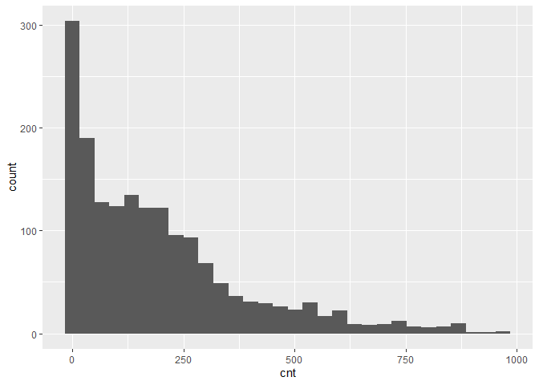

```r
ggplot(bikeTrain, mapping = aes(x = cnt)) + geom_histogram()
```

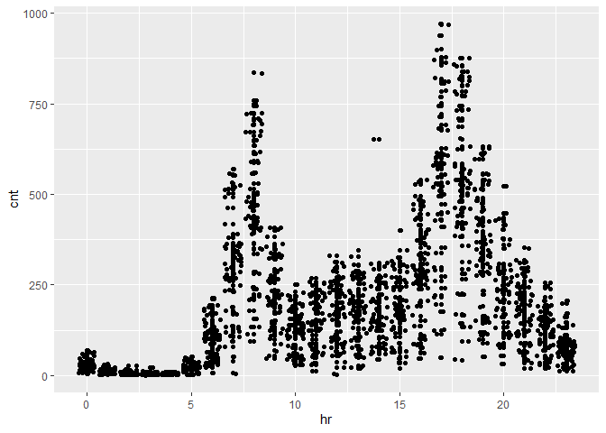

```r
ggplot(bikeTrain, aes(x = hr, y = cnt)) + geom_point() + geom_jitter()
```

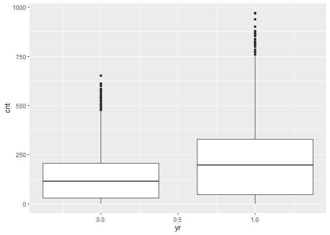

```r
ggplot(bikeTrain, aes(x = yr, y = cnt)) + geom_boxplot(aes(group = yr))
```

Next we look at correlations of different variables. Weather and windspeed do not seem correlate, so we will keep both `weathersit` and `windspeed`.

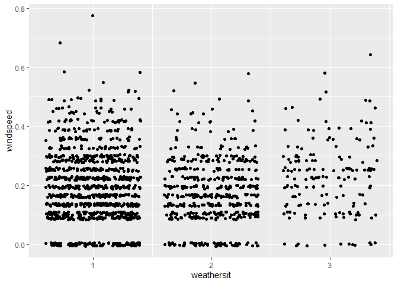

```r
ggplot(bikeTrain, aes(x = weathersit, y = windspeed)) + geom_jitter()
```

Several pairs of variables seem highly correlated–`season` and `mnth`, `holiday` and `workingday`–so we’ll remove one from each pair.

```r
cor(bikeTrain$season, bikeTrain$mnth)
```

```
## [1] 0.8843931
```

```r
cor(bikeTrain$holiday, bikeTrain$workingday)
```

```
## [1] -1
```

```r
cor(bikeTrain$temp, bikeTrain$atemp)
```

```
## [1] 0.9925321
```

The variance of `workingday` and `holiday` are too small and probably not good predictors.

```r
var(bikeTrain$holiday)
```

```
## [1] 0.008091986
```

```r
var(bikeTrain$workingday)
```

```
## [1] 0.008091986
```

Also, `instant` and `dteday` are for record-keeping. Thus, we decide to keep the following variables as the predictors: `season`, `yr`, `hr`, `weathersit`, `atemp`, `hum`, and `windspeed`.

```r
bikeTrain <- select(bikeTrain, season, yr, hr, weathersit, atemp, hum, windspeed, cnt)
bikeTest <- select(bikeTest, season, yr, hr, weathersit, atemp, hum, windspeed, cnt)
```

## Fitting models

Now we have a final training set and have chosen the predictors, we can use two models–regression tree and boosted tree–to fit the training data.

### Regression tree

A regression tree is one of the tree based methods for supervised learning with the goal of predicting a continuous response. It splits up predictor space into different regions, and the prediction of each region is often the mean of observations in that region.

```r
modelLookup("rpart")
```

```
##   model parameter                label forReg forClass probModel
## 1 rpart        cp Complexity Parameter   TRUE     TRUE      TRUE
```

```r
bikeTree <- train(cnt ~ ., data = bikeTrain, method = "rpart", trControl = trainControl(method = "LOOCV"), tuneGrid = expand.grid(cp = seq(0.01, 0.02, 0.001)))
```

Below we can see the final model; the resulting RMSE, Rsquared, and MAE of different cp; and a plot that shows the relationship between cp and RMSE.

```r
bikeTree$finalModel
```

```
## n= 1717
##
## node), split, n, deviance, yval
##       * denotes terminal node
##
##   1) root 1717 63218090.0 192.68490
##     2) hr< 6.5 489   717922.6  25.94683 *
##     3) hr>=6.5 1228 43491550.0 259.08140
##       6) atemp< 0.41665 395  7085909.0 166.26580
##        12) yr< 0.5 210  1567986.0 114.32860 *
##        13) yr>=0.5 185  4308432.0 225.22160
##          26) hr>=8.5 161  2982842.0 202.14290 *
##          27) hr< 8.5 24   664575.0 380.04170 *
##       7) atemp>=0.41665 833 31389240.0 303.09360
##        14) hr>=20.5 137   700354.2 158.47450 *
##        15) hr< 20.5 696 27259560.0 331.56030
##          30) hr< 16.5 494 10001030.0 259.59510
##            60) hr>=8.5 405  3845570.0 218.93090
##             120) hr< 15.5 343  2270075.0 199.02040
##               240) yr< 0.5 169   695013.8 154.66270 *
##               241) yr>=0.5 174   919566.1 242.10340 *
##             121) hr>=15.5 62   687276.6 329.08060 *
##            61) hr< 8.5 89  2438240.0 444.64040
##             122) yr< 0.5 47   374351.7 358.51060 *
##             123) yr>=0.5 42  1325057.0 541.02380 *
##          31) hr>=16.5 202  8443380.0 507.55450
##            62) hr>=18.5 95  1646665.0 365.44210 *
##            63) hr< 18.5 107  3174661.0 633.72900
##             126) yr< 0.5 48   430608.0 501.14580 *
##             127) yr>=0.5 59  1213848.0 741.59320 *
```

```r
bikeTree
```

```
## CART
##
## 1717 samples
##    7 predictor
##
## No pre-processing
## Resampling: Leave-One-Out Cross-Validation
## Summary of sample sizes: 1716, 1716, 1716, 1716, 1716, 1716, ...
## Resampling results across tuning parameters:
##
##   cp     RMSE       Rsquared   MAE
##   0.010   99.37055  0.7322410  67.25820
##   0.011  102.03713  0.7174872  70.80159
##   0.012  103.40609  0.7099067  71.30860
##   0.013  101.45779  0.7205748  70.50711
##   0.014  103.34339  0.7101881  71.77083
##   0.015  100.53422  0.7255055  69.56562
##   0.016  100.53422  0.7255055  69.56562
##   0.017  100.53422  0.7255055  69.56562
##   0.018  101.45490  0.7204612  69.77381
##   0.019  107.90666  0.6841045  73.78614
##   0.020  105.48874  0.6978079  72.82079
##
## RMSE was used to select the optimal model using the smallest value.
## The final value used for the model was cp = 0.01.
```

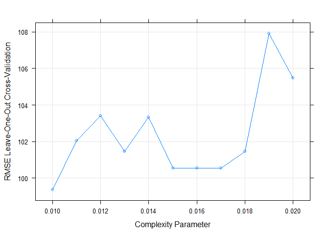

```r
plot(bikeTree)
```

Finally we use the model to predict `cnt` on the test data and calculate RMSE to check the fit of the model.

```r
predTree <- predict(bikeTree, newdata = bikeTest)
treeResult <- postResample(predTree, bikeTest$cnt)
```

### Boosted Tree

A boosted tree is one of the ensemble learning methods, in which the tree grows sequentially. Each subsequent tree is combined into the previous model to produce a modified model. The predictions are updated as the tree grows.

```r
modelLookup("gbm")
```

```
##   model         parameter                   label forReg forClass probModel
## 1   gbm           n.trees   # Boosting Iterations   TRUE     TRUE      TRUE
## 2   gbm interaction.depth          Max Tree Depth   TRUE     TRUE      TRUE
## 3   gbm         shrinkage               Shrinkage   TRUE     TRUE      TRUE
## 4   gbm    n.minobsinnode Min. Terminal Node Size   TRUE     TRUE      TRUE
```

```r
grid <- expand.grid(n.trees = c(50, 100, 150), interaction.depth = 1:4, shrinkage = c(0.1, 0.01), n.minobsinnode = c(10, 15, 20))

boostedBike <- train(cnt ~  season + yr + hr + weathersit + atemp + hum + windspeed, data = bikeTrain, method = "gbm", preProcess = c("center", "scale"), trControl = trainControl(method = "repeatedcv", number = 10, repeats = 3), tuneGrid = grid, verbose = FALSE)
```

Below we can see some information about the final model, the predictors chosen and their importance, and a plot that shows how RMSE changes with different numbers of boosting iterations and tree depths.

```r
boostedBike$finalModel
```

```
## A gradient boosted model with gaussian loss function.
## 150 iterations were performed.
## There were 7 predictors of which 7 had non-zero influence.
```

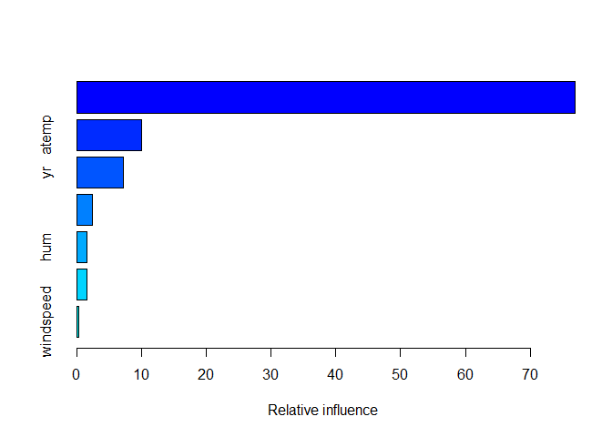

```
##                   var    rel.inf
## hr                 hr 76.9420992
## atemp           atemp 10.0594454
## yr                 yr  7.2119538
## season         season  2.4005245
## hum               hum  1.5837847
## weathersit weathersit  1.5484940
## windspeed   windspeed  0.2536984
```

```r
summary(boostedBike)
```

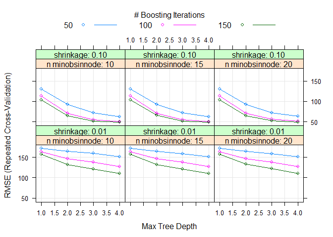

```r
plot(boostedBike)
```

Finally, we use the model to predict `cnt` on the test data and calculate RMSE to check the fit of the model.

```r
predBoostedBike <- predict(boostedBike, newdata = select(bikeTest, -cnt))
boostedResult <- postResample(predBoostedBike, bikeTest$cnt)
```

### Linear Regression Model

A linear regression model fits a straight line to he data by minimizing the sum of squared residuals.

We again use `caret` package and set the method as `lm`.

```r
library(caret)

linearBike <- train(cnt ~  season + yr + hr + weathersit + atemp + hum + windspeed, data = bikeTrain, method = "lm", preProcess = c("center", "scale"))
```

Below we can see the summary for the linear model.

```r
linearBike$finalModel
```

```
##
## Call:
## lm(formula = .outcome ~ ., data = dat)
##
## Coefficients:
## (Intercept)       season           yr           hr   weathersit        atemp
##     192.685       23.124       40.875       63.961      -10.592       48.718
##         hum    windspeed
##     -28.718        5.983
```

```r
summary(linearBike)
```

```
##
## Call:
## lm(formula = .outcome ~ ., data = dat)
##
## Residuals:
##     Min      1Q  Median      3Q     Max
## -337.01  -95.90  -38.59   49.61  616.83
##
## Coefficients:
##             Estimate Std. Error t value Pr(>|t|)
## (Intercept)  192.685      3.742  51.494  < 2e-16 ***
## season        23.124      4.092   5.651 1.87e-08 ***
## yr            40.875      3.762  10.866  < 2e-16 ***
## hr            63.961      3.897  16.413  < 2e-16 ***
## weathersit   -10.592      4.317  -2.454   0.0142 *
## atemp         48.718      4.037  12.068  < 2e-16 ***
## hum          -28.718      4.633  -6.199 7.12e-10 ***
## windspeed      5.983      3.867   1.547   0.1221
## ---
## Signif. codes:  0 '***' 0.001 '**' 0.01 '*' 0.05 '.' 0.1 ' ' 1
##
## Residual standard error: 155.1 on 1709 degrees of freedom
## Multiple R-squared:  0.3501, Adjusted R-squared:  0.3474
## F-statistic: 131.5 on 7 and 1709 DF,  p-value: < 2.2e-16
```

```r
predlinearBike <- predict(linearBike, newdata = select(bikeTest, -cnt))
linearResult <- postResample(predlinearBike, bikeTest$cnt)
```

### Comparison

We can put the testing RMSE from the two models together for comparison.

```r
comparison <- data.frame(rbind(t(treeResult), t(boostedResult)))
colnames(comparison) <- c("RMSE", "Rsquared", "MAE")
rownames(comparison) <- c("Regression Tree", "Boosted Tree")
knitr::kable(comparison)
```

|  | RMSE | Rsquared | MAE |
| --- | --- | --- | --- |
| Regression Tree | 88.92288 | 0.7534495 | 62.07661 |
| Boosted Tree | 44.83874 | 0.9364741 | 28.05756 |

### Final Model

```r
# a function to generate the name of the best model
model <- function(x, y){
  xscore <- 0
  if (x[[1]] < y[[1]]) {
    xscore = xscore + 1
  }
  if (x[[2]] > y[[2]]){
    xscore = xscore + 1
  }
  if (x[[3]] < y[[3]]){
    xscore = xscore + 1
  }
  if (xscore == 2 || xscore == 3){
    final <- c("regression tree")
  } else {
    final <- c("boosted tree")
  }
  return(final)
}
# model(treeResult, boostedResult)
```

From the output, we can conclude that the boosted tree is the better model for Tuesday data, because it has better performance in terms of RMSE, Rsquared, and MAE.